## Formalizing the user: Insights from probability-based theoretical user models

#### Scott Farley

#### April 2017

# Abstract

Constructing scenarios and hypothetical user naratives is a common technique for communicating the envisioned user experience of a tool. Using this approach, application developers rapidly build narratives of potential use cases that concretize the intended user experience. This design strategy is effective, cheap, flexible, and simple to implement. However, most narrative scenarios are not formalized – lacking a mathematical basis suitable for testing patterns of actual usership. In this paper, I present a method for underpinning scenarios with a probability framework. Under this framework, existing user personas are enhanced to include the probability of using each interface component. This approach offers at least three advantages that complement traditional scenario-based design approaches: (1) it enables formal statistical testing of use patterns, with both hypothetical data and, once the tool is put into production, real usage data, (2) it creates the potential for novel visualizations of usership patterns, showing in concrete ways the similarities and differences between scenarios, and (3) it creates the possibility of incorporating Bayesian data assimilation into interface design decisions, offering insight for future design decisions. Here, I discuss the application of this method to an in-development software tool, Ice Age Mapper, a tool for exploring multivariate, spatiotemporal ecological change in recent geologic history. Several use cases are explored and fuzzy statistical methods are shown to effectively delineate between them when cases are drawn at random from the probability distributions.

# Introduction

# Previous Work

## Scenario Based Design and Persona Based Design

## Interaction Logging

## Bayesian Assimilation in Interface Design

# Method

The method of underpinning a use-case scenario with probabilities of component use has two prerequisites. First, the application developer and stakeholders must work together to come up with a wireframe of the intended interface. A wireframe of the application, including all components, their function, and their position on the page is essential to this method. Wireframes can be either high-fi or low-fi, as long as all stakeholders are aware of the components and their functionality. The wireframes will be used to identify and name the components when assigning probabilities of use to the interface.

A second prerequisite is that the application developer have one or more clearly defined user personas or use case scenarios developed for the intended application. This use case should be crisply defined and include the affinities of the users expected to follow this use.

Once both the use cases and wireframes have been developed, the process of developing the formal user model can begin. During this phase, each application component or feature is considered and a probability distribution describing the probability that the intended users will utilize this component is proposed. Additionally, some real-valued distributions can be assigned as well, such as the width of a panel, if the proposed interface allows interactive resizing.

Whether or not a component is used by a hypothetical user following a use case scenario can be modeled as a Bernoulli distribution with probability of success $\alpha$. Thus, the probability of use of a given component is considered a discrete random variable. In this way, variation between users can be simulated while enforcing patterns between expected groups.

Real valued components can be modeled using a continuous distribution. However, few values evaluated on an interface can be infinite, as most user interaction is constrained in some way. For example, panel widths cannot exceed 100% of the page width or be less than 0% of the width. Therefore, two potentially useful distributions are the gamma distribution and the binomial distribution. The gamma distribution is truncated at zero, with support from zero to infinity. The gamma distribution is effective for modeling positively real-valued phenomena, such as the zoom level of a map component. The binomial distribution is effective for modeling the dimensions of interface components. Given the need for mobile responsive applications, it is often effective the measure the dimensions of a component in percentage terms, rather than in pixels. This percentage can be modeled as a binomial distribution with 100 trials and a probability of success on each trial of $\alpha$. Thus, as with the Bernoulli distribution described above, group-level similarities are imposed by group-to-group differences in $\alpha$, while intragroup variation may remain, as it is likely to in real life.

Once a distribution for each component of interest has been proposed by the model developer, it can be negotiated with stakeholders. While the application developer has a clear understanding of expected use, it may not align with the target user group’s expectations. Because the distributions are, ultimately, a way of communicating between developers and stakeholders, efforts should be made to refine the distributions with the input of members of of the target use cases. Alternate distributions may be proposed, or, more likely, the distribution parameters may be tweaked to more accurately reflect the stakeholder’s input. Stakeholders are likely to more effectively understand how that user group would actually utilize application components.

Communication and negotiation with the target users can be done in several ways. Informal interviews with key members of each stakeholder may be the best approach. Other social science data collection methods, including formal interviews or focus groups may also be effective. While an online survey would capture the opinion of more potential users, distribution negotiation should, in most cases, be limited to the users most qualified to comment on the potential use cases of the user group. Real world uses may be compared and used to refine the distributions using Bayesian data assimilation once the application has been released.

Once the distributions of use have been proposed and negotiated, a user model is then available for subsequent analysis. This user model is used to generate a probability generated configuration (PGC) by drawing from the distributions of each component. To create a PGC, a single draw from each component’s distribution is taken. Each draw is taken independently of all others. Therefore, a PGC is a configuration of the application potential under the given use case scenario. Variability is inherent within users within a given use case scenario. Because each draw is from a random distribution, this variation is captured while maintaining the salient features of scenario membership. Analyzing the set of PGCs, particularly if PGCs are generated from multiple scenarios, can yield insight into the variability between these scenarios.

# Case Study

Ice Age Mapper (IAM) is a novel, highly interactive tool for communication of ecological change since the Last Glacial Maximum (LGM). Paleoecological databases offer the primary source of information about the spatial responses of species and communities to large-scale climatic changes. However, the spatiotemporal characteristics, including significant positional and taxonomic uncertainty, and high dimensionality of the fossil record create significant challenges for effective visualization of floral and faunal community change over major shifts in the earth’s climate, and, more recently, in response to anthropogenic change. IAM leverages recent advances in interactive cartography, dynamic mapping, and data visualization to promote hypothesis generation and communication of ecological trends through space and time. Drawing on the vast holdings of the Neotoma Paleoecological Database (http://neotomadb.org), IAM is capable of displaying maps and information graphics of over 18 million occurrences of mammals, plants, and marine and freshwater organisms over the last 2.5 million years (Williams et al., in press). An early version of IAM is publicly available at http://paleo.geography.wisc.edu.

## Use Cases

Ice Age Mapper is a multi-level interface designed for at least two key audiences: undergraduate students and professional ecological researchers. Here, I introduce the use case scenarios for each hypothetical user.

#### User 1: Undergraduate Student

User 1 is a second year undergraduate student currently enrolled in an introductory paleoecology/paleoclimatology class. Her use of Ice Age Mapper will include (1) viewing pre-configured maps that accompany important concepts presented in class and (2) a homework assignment designed to enhance understanding of climatic influence on biotic patterns in North America since the LGM. Preconfigured maps may be introduced by the professor to illustrate and contextualize important events that are difficult to place in time, space, and history. The homework assignment will be aimed at (1) a general understanding of the dynamic nature of biotic assemblages in the recent geologic past (e.g., northward shifts) and (2) identifying specific changes and/or climatic events (e.g., Younger Dryas). The application should facilitate finding answers to both broad questions (e.g., in general, how do ranges shift since the LGM?, how have climatic patterns influenced biotic patterns since the LGM, if at all?) and specific questions (e.g., what changes did you observe in ___________’s range? Do you notice any patterns in _____________’s relative abundance at different points in time?, How did ________’s presence in the Midwest’s fossil record change?). The student will be expected to prepare written responses to the assignment but does not require access to / knowledge of the raw data. Throughout her use, User 1 will make heavy use of the contextual layers (ice sheets, northern hemisphere temperature) as a grounding point between what she knows and what she is learning.

#### User 2: Researcher

User 2 is a paleoecologist by trade and a PI on the Neotoma project. She will use Ice Age Mapper as (1) a hypothesis generation tool for her own research, primarily to reduce the time required to download and look at data from Neotoma. User 2 is a world expert in climate change and its influence of biotic patterns and has published both field work (i.e., contributed a dataset to Neotoma) and synthetic studies. Her use of Ice Age Mapper will include (a) identifying outliers (e.g., what’s that site doing way out there?), (b) sampling priorities (e.g., why hasn’t anyone found ____ here?), and (c) prior research efforts (e.g., formerly collected data and its PI). To facilitate this workflow, she requires fine-grained control over multiple filters at once. Once a possible hypothesis has been generated, she may wish to access the underlying data directly for use in statistical analyses or visualization in another software package.

## Wireframes

## Initial Proposals for Distributions

In this problem, we’ll try to identify between our two key user groups:

- *Student*s: Using the interface for a class assignment
- *Research*ers; Using the interface for an in-depth analysis of paleoecological patterns

| Variable | Interpretation | Distribution | Param1 | Param2 |
| --- | --- | --- | --- | --- |
| hasAuthor | Does the map have an author | Bernoulli | 0.9 | NA |
| hasOrganization | Does the map have an institution associated with it | Bernoulli | 0.7 | NA |
| hasTitle | Does the map have a title associated with it | Bernoulli | 0.6 | NA |
| hasDescription | Does the map have a description associated with it | Bernoulli | 0.4 | NA |
| usedTaxonIDNumber | Did the map create use the search by name function or the browse function to arrive at the map configuration | Bernoulli | 0.9 | NA |
| configdata.state.openSite | Is the site details panel open | Bernoulli | 0.2 | NA |
| configdata.state.layout.westPanelIsOpen | Is the site details panel open | Bernoulli | 0.2 | NA |
| configdata.state.layout.southPanelIsOpen | Is the bottom timeline panel open | Bernoulli | 0.8 | NA |
| configdata.state.layout.eastPanelIsOpen | Is the right dashboard panel open | Bernoulli | 0.8 | NA |
| configdata.state.doSearch | Does the map come preconfigured with data | Bernoulli | 0.1 | NA |
| configdata.state.map.zoom | What zoom level is the map at | Gamma | 3.0 | 2 |
| configdata.config.timer.totalElapsed | How much time has elapsed since the session started? | Gamma | 180.0 | 120 |
| configdata.config.timer.loadElapsed | How much time has elapsed since loading data onto the map | Gamma | 120.0 | 120 |
| configdata.config.layout.eastPanelSize | Percentage of screen covered by dashboard | Binomial | 0.5 | NA |
| configdata.config.layout.westPanelSize | Percentage of screen covered by site details | Binomial | 0.3 | NA |
| configdata.config.layout.southPanelSize | Percentage of screen covered by bottom timeline | Binomial | 0.4 | NA |
| usedAgeFilter | Does the configuration use the time filter | Bernoulli | 0.5 | NA |
| usedLatitudeFilter | Does the configuration use the latitude filter | Bernoulli | 0.4 | NA |
| usedAbundanceFilter | Does the configuration use the abundance filter | Bernoulli | 0.1 | NA |
| usedPIFilter | Does the configuartion use the investigator filter | Bernoulli | 0.1 | NA |
| usedRecordTypeFilter | Does the configuration use the record type filter? | Bernoulli | 0.2 | NA |

| Variable | Interpretation | Distribution | Param1 | Param2 |
| --- | --- | --- | --- | --- |
| hasAuthor | Does the map have an author | Bernoulli | 0.95 | NA |
| hasOrganization | Does the map have an institution associated with it | Bernoulli | 0.95 | NA |
| hasTitle | Does the map have a title associated with it | Bernoulli | 0.90 | NA |
| hasDescription | Does the map have a description associated with it | Bernoulli | 0.90 | NA |
| usedTaxonIDNumber | Did the map create use the search by name function or the browse function to arrive at the map configuration | Bernoulli | 0.20 | NA |
| configdata.state.openSite | Is the site details panel open | Bernoulli | 0.40 | NA |
| configdata.state.layout.westPanelIsOpen | Is the site details panel open | Bernoulli | 0.30 | NA |
| configdata.state.layout.southPanelIsOpen | Is the bottom timeline panel open | Bernoulli | 0.40 | NA |
| configdata.state.layout.eastPanelIsOpen | Is the right dashboard panel open | Bernoulli | 0.65 | NA |
| configdata.state.doSearch | Does the map come preconfigured with data | Bernoulli | 0.20 | NA |
| configdata.state.map.zoom | What zoom level is the map at | Gamma | 6.00 | 2 |
| configdata.config.timer.totalElapsed | How much time has elapsed since the session started? | Gamma | 600.00 | 180 |
| configdata.config.timer.loadElapsed | How much time has elapsed since loading data onto the map | Gamma | 500.00 | 120 |
| configdata.config.layout.eastPanelSize | Percentage of screen covered by dashboard | Binomial | 0.50 | NA |
| configdata.config.layout.westPanelSize | Percentage of screen covered by site details | Binomial | 0.30 | NA |
| configdata.config.layout.southPanelSize | Percentage of screen covered by bottom timeline | Binomial | 0.40 | NA |
| usedAgeFilter | Does the configuration use the time filter | Bernoulli | 0.70 | NA |
| usedLatitudeFilter | Does the configuration use the latitude filter | Bernoulli | 0.30 | NA |
| usedAbundanceFilter | Does the configuration use the abundance filter | Bernoulli | 0.20 | NA |
| usedPIFilter | Does the configuartion use the investigator filter | Bernoulli | 0.20 | NA |
| usedRecordTypeFilter | Does the configuration use the record type filter? | Bernoulli | 0.20 | NA |

Once the probabilities have been assigned, they are read into R. R generated a probability density function from the model then draws *N* random samples from that distribution. In this way, we have *N* ‘users’ in each group that we can analyze as real data.

| hasAuthor | hasOrganization | hasTitle | hasDescription | usedTaxonIDNumber |
| --- | --- | --- | --- | --- |
| TRUE | TRUE | FALSE | TRUE | TRUE |
| FALSE | TRUE | FALSE | FALSE | TRUE |
| TRUE | FALSE | FALSE | TRUE | TRUE |
| TRUE | TRUE | TRUE | TRUE | TRUE |
| TRUE | FALSE | FALSE | FALSE | TRUE |
| TRUE | TRUE | FALSE | FALSE | TRUE |

## Visually Assess the Data

Using this data, we can graphically assess whether it appears that there are differences in the two models (we built the models, so we know that they are – but we can see how that appears as a PDF here). When we get real data, we can see how the theoretical models align with the real usership data. Also, we can, I think, integrate the new data using Bayesian data assimilation. More on that as the idea develops.

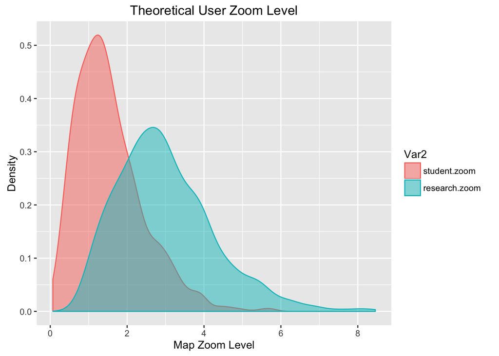

Here, we can see the difference in zoom levels inherent between the two groups of users. Students are more interested in continental level inference, while researchers are more likely to focus on a study area they are already familiar with, or identify a new one.

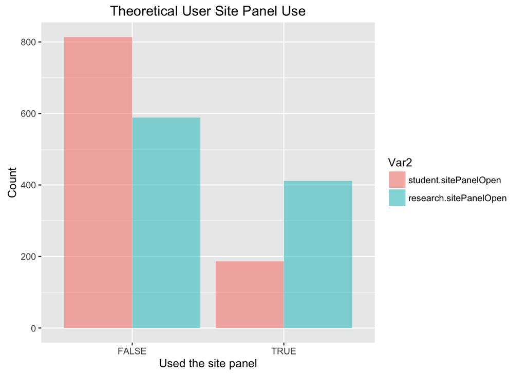

We can also see how likely one group is to use one of the components of our interface, such as the use of the site details panel.

## Principle Components Analysis

Here, we have many variables that may contribute to the variation in the interface design. First, we will do a PCA on the data to reduce its dimensionality and, hopefully, see meaningful differences between our groups of users.

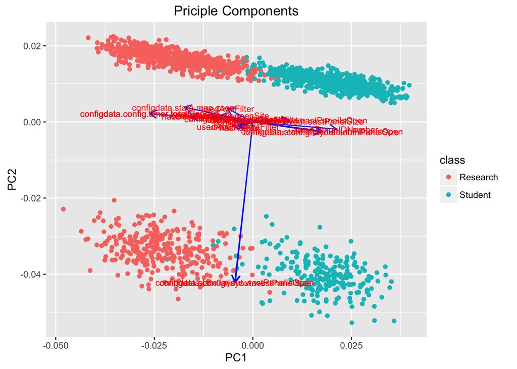

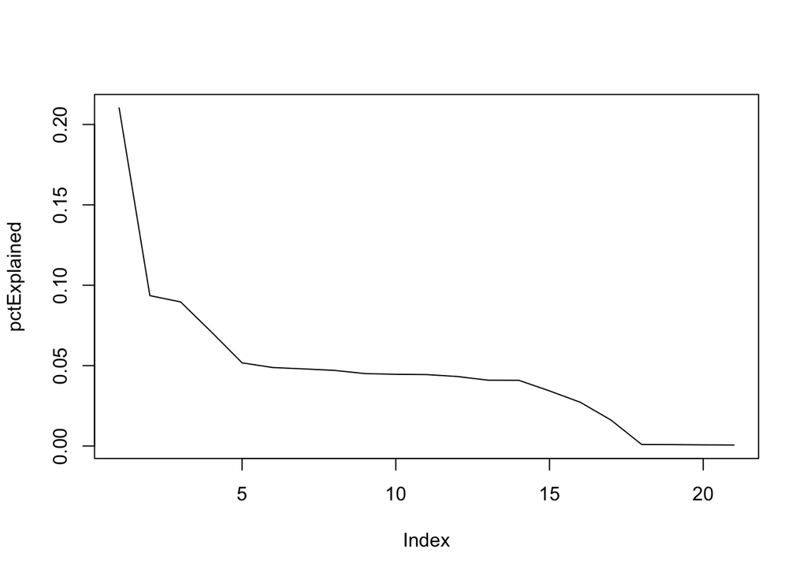

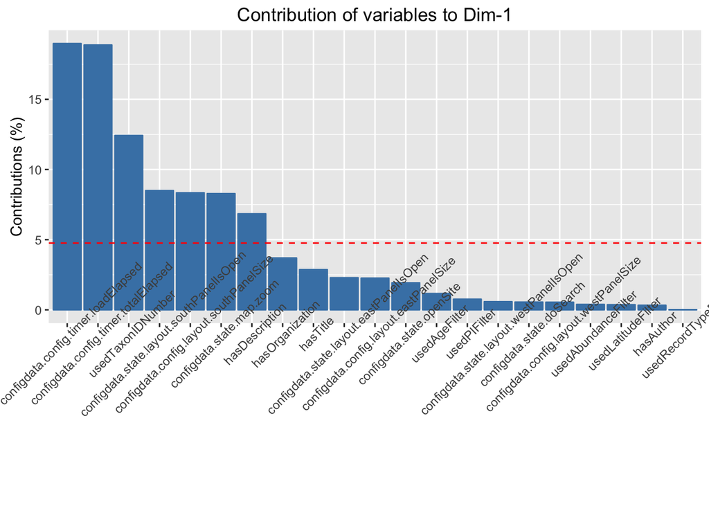

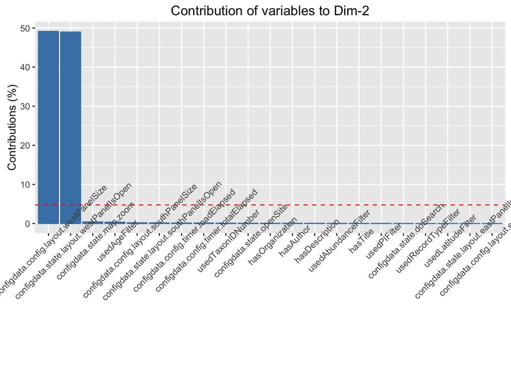

## Cluster Analysis

Next, we can attempt to cluster the groups into meaningful groups using an unsupervised learning approach. In real life, users are not crisply grouped into classes. Instead, they may have some attributes on one class and some attributes of another. For example, is a graduate student a *research*er or a *student*? In reality, she will likely display usership characteristics of both classes.

Here we will use fuzzy logic to cluster the users into two groups, letting each use case have a fuzzy degree of membership in each of the classes. For example, the graduate student may have a 25% membership in the student category and a 75% membership in the research class.

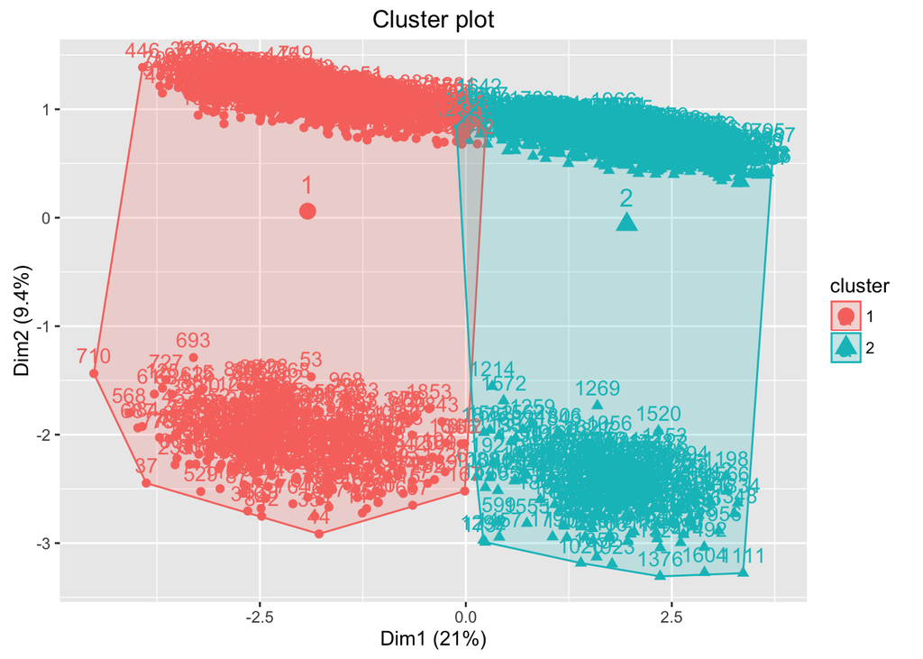

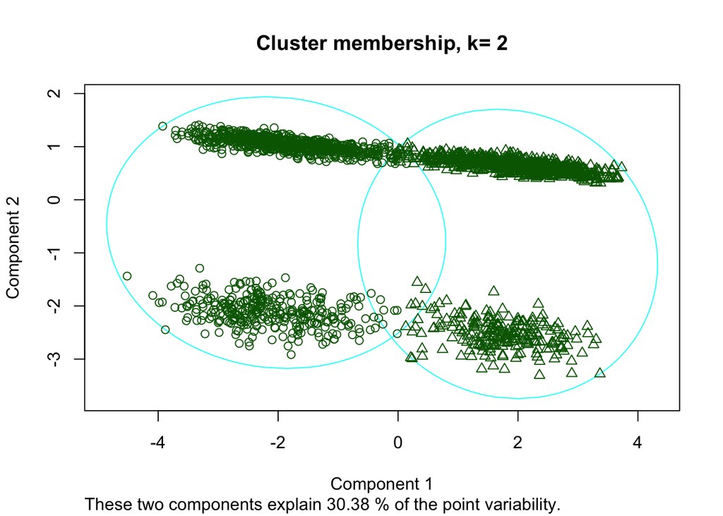

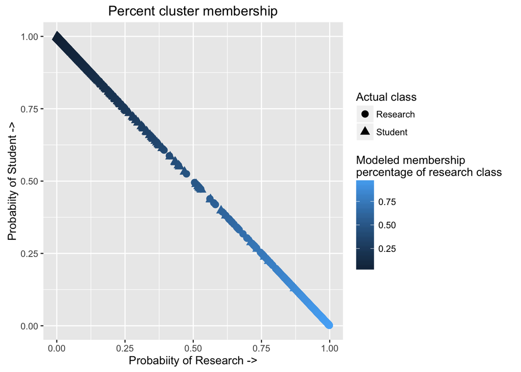

## Bayesian Data Assimilation

# Discussion

## Statistical Testing of Usage Differences

## Novel Visualization Potential

## Bayesian Assimilation with Real Usage Patterns

# Conclusion

# References